# Abdelghany_HW3

## Maximum margin classifiers

1. Run the following code to create a simple dataset.

```r
X1 <- c(3,1,3,1,2,4,4)
X2 <- c(4,2,3,4,1,3,1)
Y <- c(rep("Red",4),rep("Blue",3))
dat <- data.frame(X1,X2,Y)
print(dat)
```

```
##   X1 X2    Y
## 1  3  4  Red
## 2  1  2  Red
## 3  3  3  Red
## 4  1  4  Red
## 5  2  1 Blue
## 6  4  3 Blue
## 7  4  1 Blue
```

2. Plot the data. Color-code the points by their outcome value `Y`.

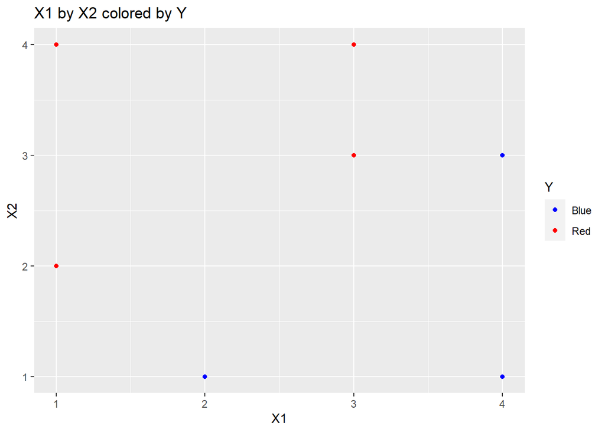

```r
ggplot(dat, aes(x = X1, y = X2, color = Y)) +
    geom_point() +
    scale_color_manual(values = c("blue", "red")) +
    labs(title = "X1 by X2 colored by Y")
```

3. (3 points) Fit a maximal margin classifier with a linear decision boundary to this dataset using the `svm` function from `e1071`. Use the option `scale=FALSE` so that the model does not do post-processing of the training data. Plot the fitted model.

```r
svm_model <- svm(factor(Y) ~ ., data = dat, scale = FALSE, kernel = "linear", cost = 10)
# see below for plot of svm_model (in number 4) to compare to added point model
```

4. (1 point) Use the `coef` function to extract model coefficients from the maximum margin classifier.

```r
coef(svm_model)
```

```
## (Intercept)          X1          X2
##   0.9994192  -1.9996832   1.9998416
```

5. (2 points) Suppose we are going to add another observation to the dataset and refit the maximum margin classifier. Give a new datapoint that, when added to this dataset, will not change the decision boundary. Refit the model to double check. Call this new datapoint `point1`.

```r
# generate point1 as a list
point1 <- list(X1 = 0, X2 = 5, Y = "Red")

# add point1 to the dataset and call it dat2
dat2 <- rbind(dat, point1)

# fit a new SVM model
svm_model2 <- svm(factor(Y) ~ ., data = dat2, scale = FALSE, kernel = "linear", cost = 10)

# create a data table showing that the coefficients are nearly equal
data.table(
    labels = c("Intercept", "X1", "X2"),
    SVM_model1 = coef(svm_model),
    SVM_model2 = coef(svm_model2)
)
```

```
##       labels SVM_model1 SVM_model2
## 1: Intercept  0.9994192  0.9995424
## 2:        X1 -1.9996832 -1.9997504
## 3:        X2  1.9998416  1.9998752
```

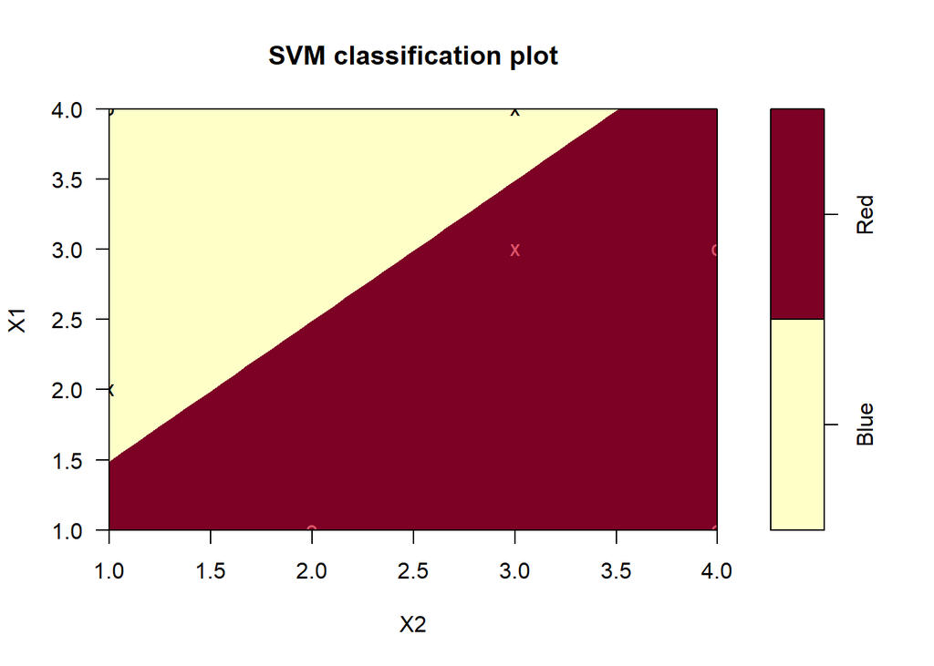

```r
# plot the two SVM models showing a nearly equivalent decision boundary
plot(svm_model, data = dat)
```

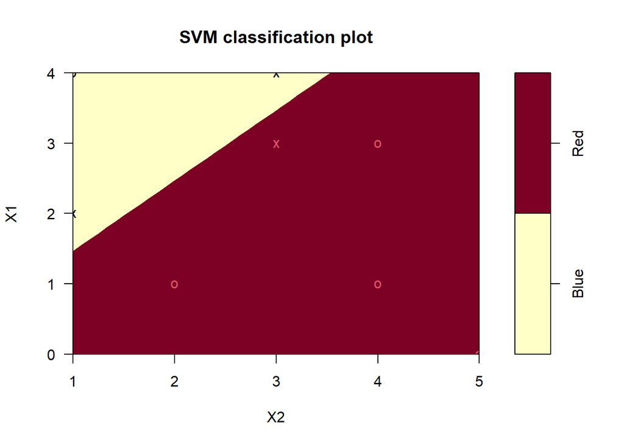

```r
plot(svm_model2, data = dat2)
```

6. (2 points) Now give a new datapoint that, when added to dataset `dat`, WILL change the decision boundary. Call this new datapoint `point2`. Pick an example point where the new dataset remains linearly separable.

```r
# generate point2 as a list
point2 <- list(X1 = 1, X2 = 1.5, Y = "Blue")

# add point2 to the dataset and call it dat3
dat3 <- rbind(dat, point2)

# fit a new SVM model
svm_model3 <- svm(factor(Y) ~ ., data = dat3, scale = FALSE, kernel = "linear", cost = 10)

# create a data table showing that the coefficients are different
data.table(
    labels = c("Intercept", "X1", "X2"),
    SVM_model1 = coef(svm_model),
    SVM_model3 = coef(svm_model3)
)
```

```
##       labels SVM_model1 SVM_model3
## 1: Intercept  0.9994192  -4.999580
## 2:        X1 -1.9996832  -1.999914
## 3:        X2  1.9998416   3.999742
```

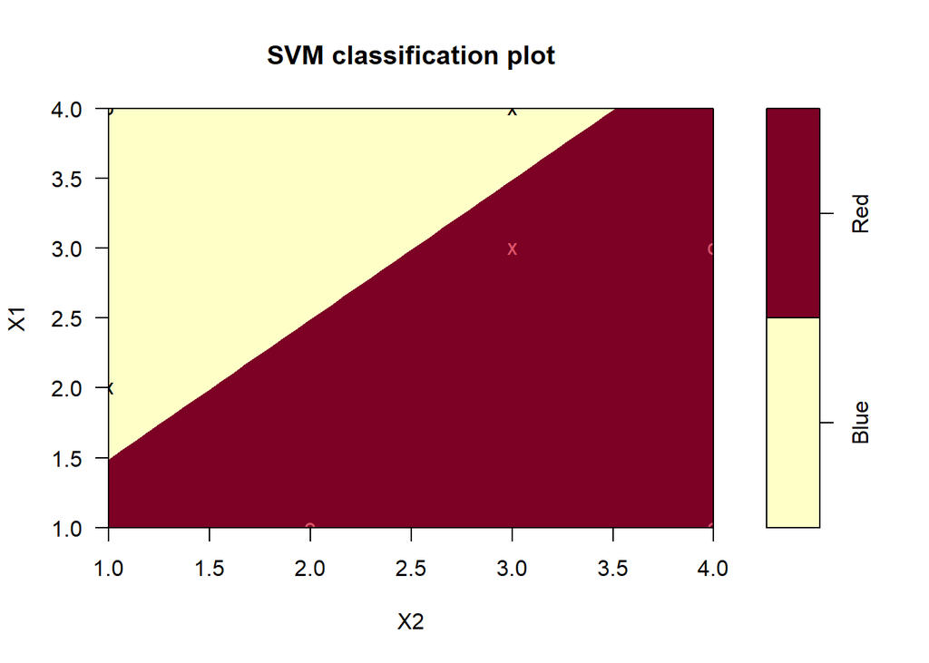

```r
# plot the two SVM models showing two different decision boundaries
plot(svm_model, data = dat)
```

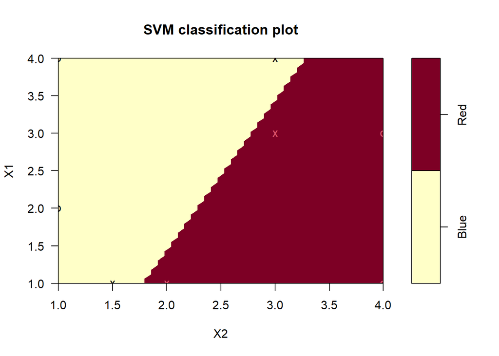

```r
plot(svm_model3, data = dat3)
```

## Support vector machines

7. Read in the dementia data “dementia2.csv” into a data frame called `dementia_dat`. This data is from the UCSF Memory and Aging Center. The goal was to predict the type of dementia based on patterns of brain loss as measured through structural MRI.

```r
dementia_dat <- fread("dementia2_hw3.csv")
dementia_dat <- data.frame(dementia_dat)
```

8. (1 point) We will now predict the dementia diagnosis based on the available predictors. The diagnosis is given in the multiclass outcome of `MacCohort_kr`. To start, generate a table of the elements in the `MacCohort_kr` variable.

```r
# make MacCohort_kr a factor
dementia_dat$MacCohort_kr <- factor(dementia_dat$MacCohort_kr)
class(dementia_dat$MacCohort_kr)
```

```
## [1] "factor"
```

```r
# make dementia a factor
dementia_dat$Dementia <- factor(dementia_dat$Dementia)
class(dementia_dat$Dementia)
```

```
## [1] "factor"
```

```r
# generate a table
table(dementia_dat$MacCohort_kr)
```

```
##
##         AD      bvFTD    CONTROL nfPPAunspc        PSP      svPPA
##        151         68        315         38         44         44
```

9. (1 point) Set the random seed to 7 and then split the data into 2 sets (440 train, and 220 test)

```r
set.seed(7)

# create the sampling index
sampler <- createDataPartition(dementia_dat$MacCohort_kr,
                               times = 1,
                               p = 436/660,
                               list = FALSE)

# training set
dementia_dat_train <- dementia_dat[sampler, ]
nrow(dementia_dat_train)
```

```
## [1] 440
```

```r
# test set
dementia_dat_test <- dementia_dat[-sampler, ]
nrow(dementia_dat_test)
```

```
## [1] 220
```

10. (3 points) Fit a support vector machine to predict `MacCohort_kr` using predictors `Left_MTG_middle_temporal_gyrus`, `Left_Amygdala` and `Left_AIns_anterior_insula`, with a radial basis kernel. Use 3-fold CV to tune the value of the `C` and `sigma` hyperparameters. Use the `caret` package with `method=svmRadial` and tune over the values `C = 1e-2,1e-1,1,10,100,1000,10000` and `sigma=1e-4,1e-3,1e-2,1e-1, 1,10`. (You may need the `kernlab` package to run this.)

```r
# perform 3-fold cross-validation
fitControl <- trainControl(method = "cv", number = 3)

# set the range of C values to tune across
C.values <- data.frame(C = c(1e-2, 1e-1, 1, 10, 100, 1000, 10000))

# set the range of sigma values to tune across
sigma.values <- data.frame(sigma = c(1e-4, 1e-3, 1e-2, 1e-1, 1, 10))

# generate a matrix of C and sigma values to use for hyperparameter tuning
tune.matrix <- merge(C.values, sigma.values, all = TRUE)

# create a data frame with only the variables of interest
dementia_dat_train <- dementia_dat_train[,c("MacCohort_kr", "Left_MTG_middle_temporal_gyrus",
                                            "Left_Amygdala", "Left_AIns_anterior_insula")]
dementia_dat_test <- dementia_dat_test[,c("MacCohort_kr", "Left_MTG_middle_temporal_gyrus",
                                            "Left_Amygdala", "Left_AIns_anterior_insula")]

# tune the SVM model using 3-fold cross-validation and the tune.matrix above
cv.svm.model <- train(x = dementia_dat_train[,2:4],
                      y = dementia_dat_train$MacCohort_kr,
                      trControl = fitControl,
                      method = "svmRadial",
                      tuneGrid = tune.matrix)

tuned.svm.model <- cv.svm.model$finalModel
tuned.svm.model
```

```
## Support Vector Machine object of class "ksvm"
##
## SV type: C-svc  (classification)
##  parameter : cost C = 10000
##
## Gaussian Radial Basis kernel function.
##  Hyperparameter : sigma =  0.01
##
## Number of Support Vectors : 260
##
## Objective Function Value : -429112 -790626.8 -432274.9 -497261.7 -351780.6 -359716.7 -307962 -328238.4 -139811.8 -415171 -594865.3 -69505.24 -358932.5 -95289.48 -74165.61
## Training error : 0.281818
```

11. (1 points) Determine the predictions of the SVM fit on the test dataset. What is the test accuracy?

```r
# determine the predictions
svm.test.predictions <- predict(tuned.svm.model,
                                newdata = dementia_dat_test[,-1],
                                type = "response")

# Find the test accuracy manually
mean(svm.test.predictions == dementia_dat_test[,1])
```

```
## [1] 0.6590909
```

```r
# Find the test accuracy using confusionMatrix()
confusionMatrix(data = svm.test.predictions, reference = dementia_dat_test[,1])
```

```
## Confusion Matrix and Statistics
##
##             Reference
## Prediction   AD bvFTD CONTROL nfPPAunspc PSP svPPA
##   AD         27     4       7          2   1     4
##   bvFTD       3    11       0          7   1     1
##   CONTROL    17     7      99          3  12     1
##   nfPPAunspc  0     0       0          0   0     0
##   PSP         0     0       0          0   0     0
##   svPPA       4     1       0          0   0     8
##
## Overall Statistics
##
##                Accuracy : 0.6591
##                  95% CI : (0.5924, 0.7215)
##     No Information Rate : 0.4818
##     P-Value [Acc > NIR] : 8.668e-08
##
##                   Kappa : 0.4618
##
##  Mcnemar's Test P-Value : NA
##
## Statistics by Class:
##
##                      Class: AD Class: bvFTD Class: CONTROL Class: nfPPAunspc
## Sensitivity             0.5294       0.4783         0.9340           0.00000
## Specificity             0.8935       0.9391         0.6491           1.00000
## Pos Pred Value          0.6000       0.4783         0.7122               NaN
## Neg Pred Value          0.8629       0.9391         0.9136           0.94545
## Prevalence              0.2318       0.1045         0.4818           0.05455
## Detection Rate          0.1227       0.0500         0.4500           0.00000
## Detection Prevalence    0.2045       0.1045         0.6318           0.00000
## Balanced Accuracy       0.7115       0.7087         0.7915           0.50000
##                      Class: PSP Class: svPPA
## Sensitivity             0.00000      0.57143
## Specificity             1.00000      0.97573
## Pos Pred Value              NaN      0.61538
## Neg Pred Value          0.93636      0.97101
## Prevalence              0.06364      0.06364
## Detection Rate          0.00000      0.03636
## Detection Prevalence    0.00000      0.05909
## Balanced Accuracy       0.50000      0.77358
```

12. (3 points) What is the accuracy of a model that randomly guesses the class label simply based on the fraction of observations in each class? Is the SVM doing better than random guessing?

```r
# pull possible predictions from the data set
possible.pred <- names(table(dementia_dat_train$MacCohort_kr))
# generate vector of probabilities for each possible prediction using prevalence
probabilities <- table(dementia_dat_train$MacCohort_kr)/sum(table(dementia_dat_train$MacCohort_kr))
# sample each possible prediction at the probability of its respective prevalence
mac_kr <- sample(possible.pred, size = sum(table(dementia_dat_test$MacCohort_kr)),
                 replace = TRUE, prob = probabilities)

# Find the test accuracy manually
mean(factor(mac_kr) == dementia_dat_test[,2])
```

```
## [1] 0
```

```r
# Find the test accuracy using confusionMatrix()
confusionMatrix(data = factor(mac_kr), reference = dementia_dat_test[,1])
```

```
## Confusion Matrix and Statistics
##
##             Reference
## Prediction   AD bvFTD CONTROL nfPPAunspc PSP svPPA
##   AD         12     5      27          4   2     4
##   bvFTD       5     3       8          1   3     0
##   CONTROL    22    12      54          4   5     6
##   nfPPAunspc  5     0       7          1   1     1
##   PSP         1     3       3          0   2     3
##   svPPA       6     0       7          2   1     0
##
## Overall Statistics
##
##                Accuracy : 0.3273
##                  95% CI : (0.2657, 0.3936)
##     No Information Rate : 0.4818
##     P-Value [Acc > NIR] : 1
##
##                   Kappa : 0.0337
##
##  Mcnemar's Test P-Value : NA
##
## Statistics by Class:
##
##                      Class: AD Class: bvFTD Class: CONTROL Class: nfPPAunspc
## Sensitivity            0.23529      0.13043         0.5094          0.083333
## Specificity            0.75148      0.91371         0.5702          0.932692
## Pos Pred Value         0.22222      0.15000         0.5243          0.066667
## Neg Pred Value         0.76506      0.90000         0.5556          0.946341
## Prevalence             0.23182      0.10455         0.4818          0.054545
## Detection Rate         0.05455      0.01364         0.2455          0.004545
## Detection Prevalence   0.24545      0.09091         0.4682          0.068182
## Balanced Accuracy      0.49339      0.52207         0.5398          0.508013
##                      Class: PSP Class: svPPA
## Sensitivity            0.142857      0.00000
## Specificity            0.951456      0.92233
## Pos Pred Value         0.166667      0.00000
## Neg Pred Value         0.942308      0.93137
## Prevalence             0.063636      0.06364
## Detection Rate         0.009091      0.00000
## Detection Prevalence   0.054545      0.07273
## Balanced Accuracy      0.547157      0.46117
```

After generating a vector of predictions using the prevalence as the probability that each prediction can be selected, the accuracy is ~33%. This is considerably less than the accuracy of the SVM model, ~66%. The SVM model is performing about twice as better than random guesses based on prevalence.

## Classification and Regression Trees

13. Read in the breast cancer imaging data “ispy1doctored.csv” into a data frame called `dat`. The iSPY1 trial was a prospective study to test if we could use MRIs to predict response to treatment and risk-of-recurrence in patients with stage 2 or 3 breast cancer receiving neoadjuvant chemotherapy (NACT).

```r
dat <- fread("ispy1doctored.csv")
```

14. Load the `rpart` package. Set the random seed to 10.

```r
library(rpart)
library(rpart.plot)
set.seed(10)
```

15. (1 point) Generate a histogram of the `MRI_LD_Tfinal` variable that will be our outcome to predict.

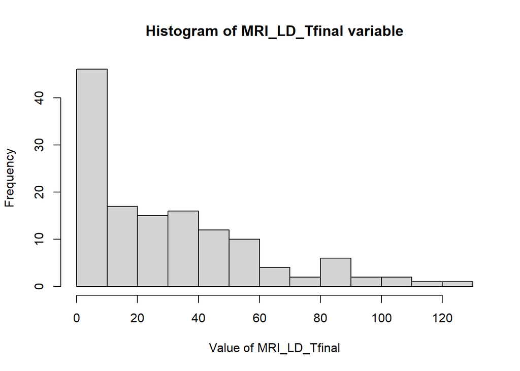

```r
hist(dat$MRI_LD_Tfinal, plot=TRUE,
     main = "Histogram of MRI_LD_Tfinal variable",
     xlab = "Value of MRI_LD_Tfinal")
```

16. (1 point) Split the dataset into a training set of size 70 and a test set consisting of the remaining data.

```r
# create the sampling index
sampler2 <- createDataPartition(dat$MRI_LD_Tfinal,
                                times = 1,
                                p = 68/134,
                                list = FALSE)

# training set
dat_train <- dat[sampler2, ]
nrow(dat_train)
```

```
## [1] 70
```

```r
# test set
dat_test <- dat[-sampler2, ]
nrow(dat_test)
```

```
## [1] 64
```

17. (3 points) Fit a regression tree to the training data with `MRI_LD_Tfinal` as outcome and all other variables as candidate predictors. Make sure that you specify the correct method for regression. Plot the fitted tree with text labels.

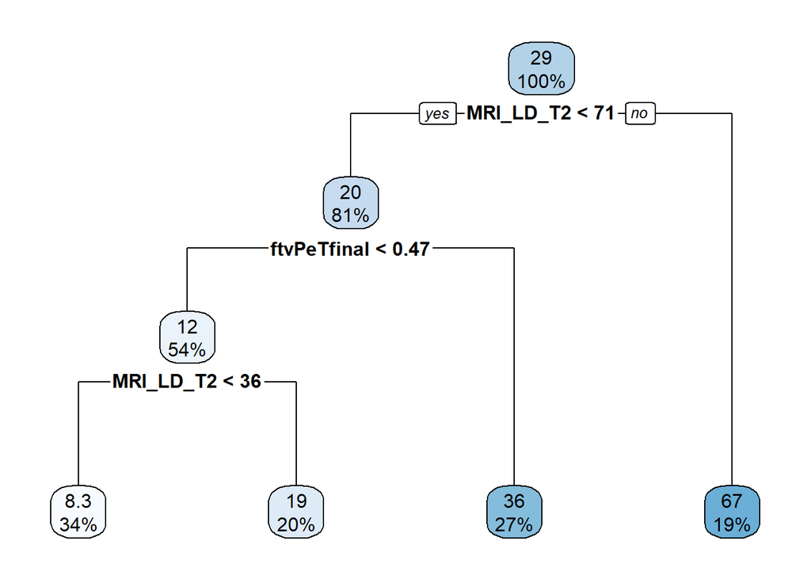

```r
dat_tree <- rpart(MRI_LD_Tfinal ~ ., data = dat_train, method = "anova")
rpart.plot(dat_tree)
```

18. (1 point) How many partitions does the fitted tree have? The fitted tree has four partitions.
19. (2 points) Determine the mean squared error (MSE) of the fitted tree based on the test data.

```r
# HR_HER2status factor had an empty level in the test data that needed to be removed
# in order for predict() to work properly
predictions <- predict(dat_tree, newdata = dat_test[HR_HER2status!=""])

# manual calculation of mean squared error, again removing empty HR_HER2status
mean((predictions - dat_test[HR_HER2status!=""]$MRI_LD_Tfinal)^2)
```

```
## [1] 377.1097
```

## Bagging

20. Load the `randomForest` package and set the random seed to 4

```r
library(randomForest)
set.seed(4)
```

21. (2 points) Perform bagging with `MRI_LD_Tfinal` as outcome and all other variables as candidate predictors.

```r
dat_bagging <- randomForest(MRI_LD_Tfinal ~., data = dat_train, mtry = 16, importance = TRUE)
dat_bagging
```

```
##
## Call:
##  randomForest(formula = MRI_LD_Tfinal ~ ., data = dat_train, mtry = 16,      importance = TRUE)
##                Type of random forest: regression
##                      Number of trees: 500
## No. of variables tried at each split: 16
##
##           Mean of squared residuals: 449.089
##                     % Var explained: 36.83
```

22. (1 point) Determine the mean squared error (MSE) of the bagging based on the test data.

```r
predictions2 <- predict(dat_bagging, newdata = dat_test[HR_HER2status!=""])
mean((predictions2 - dat_test[HR_HER2status!=""]$MRI_LD_Tfinal)^2)
```

```
## [1] 277.6161
```

## Random Forests

23. (2 points) Set the seed to 4 again and perform random forests with 6 candidate predictors per tree, `MRI_LD_Tfinal` as outcome and all other variables as candidate predictors.

```r
set.seed(4)
dat_forest_6 <- randomForest(MRI_LD_Tfinal ~., data = dat_train, mtry = 6, importance = TRUE)
dat_forest_6
```

```
##
## Call:
##  randomForest(formula = MRI_LD_Tfinal ~ ., data = dat_train, mtry = 6,      importance = TRUE)
##                Type of random forest: regression
##                      Number of trees: 500
## No. of variables tried at each split: 6
##
##           Mean of squared residuals: 450.9354
##                     % Var explained: 36.57
```

24. (1 point) Determine the mean squared error (MSE) of the random forest based on the test data.

```r
predictions3 <- predict(dat_forest_6, newdata = dat_test[HR_HER2status!=""])
mean((predictions3 - dat_test[HR_HER2status!=""]$MRI_LD_Tfinal)^2)
```

```
## [1] 327.7681
```

25. (2 points) Plot the variable importance from the random forest. Use the importance measured in terms of the mean increase in mean squared error. Based on this importance measure, which variable is most important? Which variable is least important?

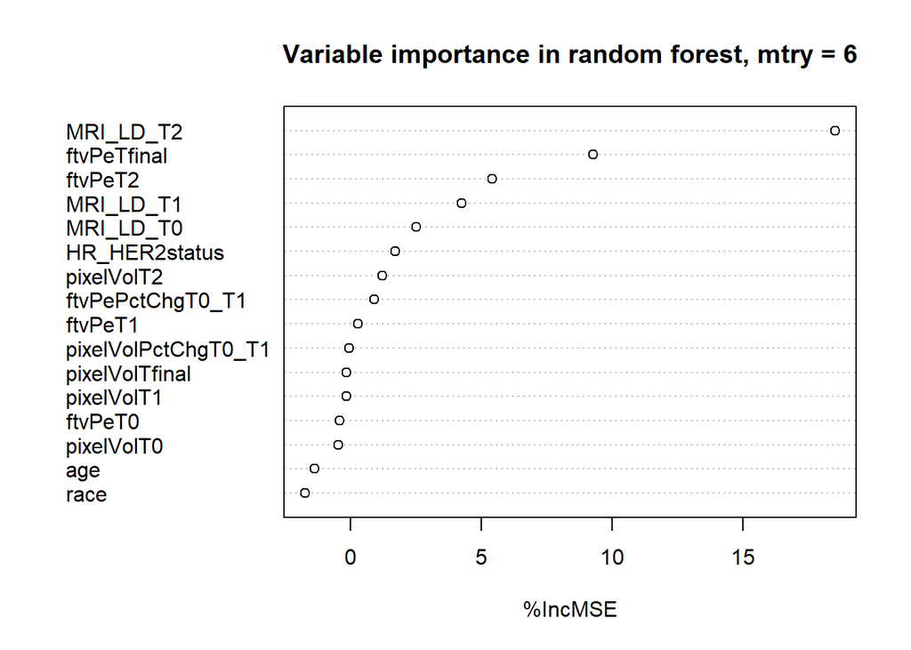

```r
varImpPlot(dat_forest_6, type = 1, main = "Variable importance in random forest, mtry = 6")
```

For the model using 6 predictors, `dat_forest_6`, the most important variable based on percent increase in mean squared is `MRI_LD_T2`. The least important variable based on this metric is `race`.